# Exploratory Analysis of Suicide Data

Zikai Lin

11/8/2020

# 1 **Import & Tidy**

The majority of the data used in this analysis was obtained from the World Health Organisation.

# 2 Global Trend

Here we want to investigate the global trend of the suicide data.

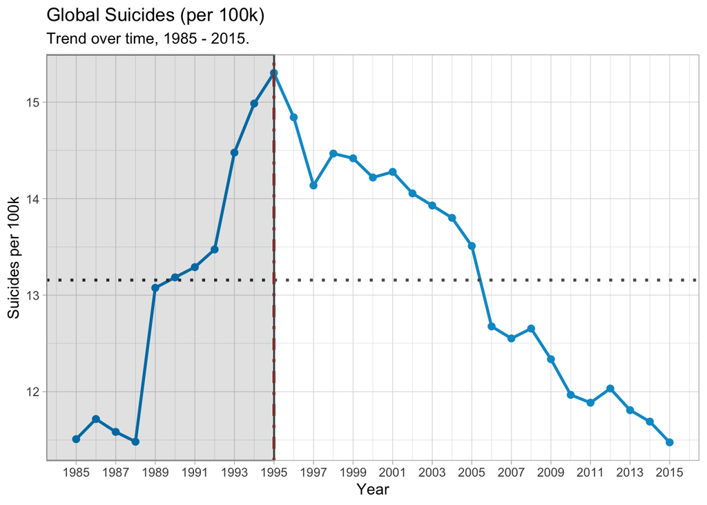

```r
data %>%
  group_by(year) %>%
  summarize(population = sum(population),
            suicides = sum(suicides_no),
            suicides_per_100k = (suicides / population) * 100000) %>%
  ggplot(aes(x = year, y = suicides_per_100k)) +
  geom_line(col = "deepskyblue3", size = 1) +
  geom_point(col = "deepskyblue3", size = 2) +
  geom_hline(yintercept = global_average, linetype = 3, color = "grey35", size = 1) +
  geom_vline(xintercept = 1995, color = "red", linetype = 4, size = 1)+
  geom_rect(aes(xmin=-Inf, xmax=1995, ymin=-Inf, ymax=Inf), alpha=0.003, color = "grey35")+
  labs(title = "Global Suicides (per 100k)",
       subtitle = "Trend over time, 1985 - 2015.",
       x = "Year",
       y = "Suicides per 100k") +
  scale_x_continuous(breaks = seq(1985, 2015, 2)) +
  scale_y_continuous(breaks = seq(10, 20))
```

According to the plot, we be able to hypothesize that the trend of gobal suicide rate increase from 1985-1995 and decreased after 1995.

# 3 By continents

However, this is just a global trend, in order to investigate if the trends are different within differnt continents. We can plot the trend of suicide rate for different continents.

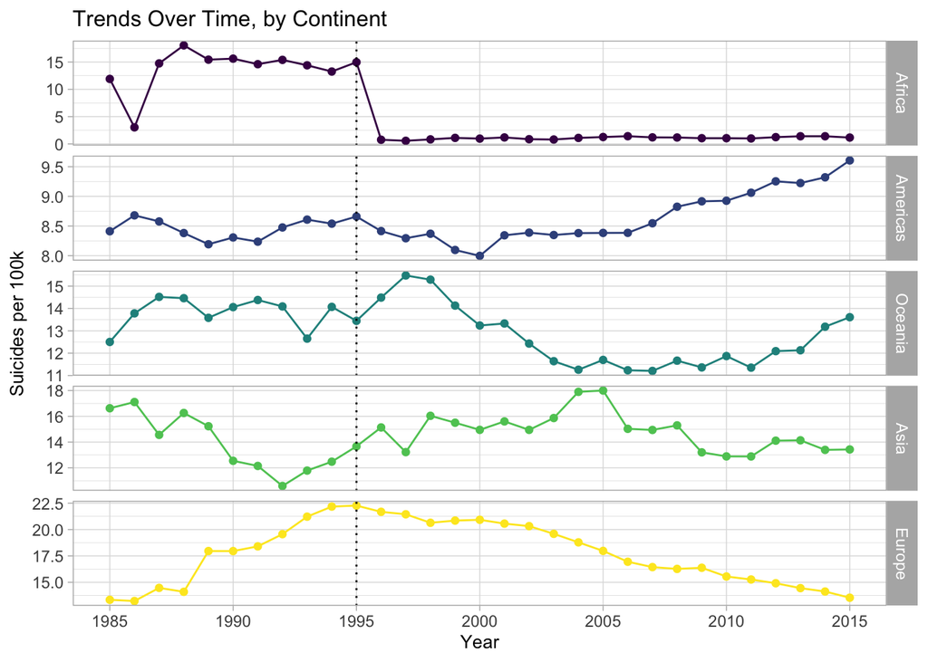

```r
continent <- data %>%
  group_by(continent) %>%
  summarize(suicide_per_100k = (sum(as.numeric(suicides_no)) / sum(as.numeric(population))) * 100000) %>%
  arrange(suicide_per_100k)

continent$continent <- factor(continent$continent, ordered = T, levels = continent$continent)


continent_time <- data %>%
  group_by(year, continent) %>%
  summarize(suicide_per_100k = (sum(as.numeric(suicides_no)) / sum(as.numeric(population))) * 100000)

continent_time$continent <- factor(continent_time$continent, ordered = T, levels = continent$continent)

continent_time_plot <- ggplot(continent_time, aes(x = year, y = suicide_per_100k, col = factor(continent))) +
  facet_grid(continent ~ ., scales = "free_y") +
  geom_line() +
  geom_point() +
  geom_vline(xintercept = 1995, linetype=3)+
  labs(title = "Trends Over Time, by Continent",
       x = "Year",
       y = "Suicides per 100k",
       color = "Continent") +
  theme(legend.position = "none", title = element_text(size = 10)) +
  scale_x_continuous(breaks = seq(1985, 2015, 5), minor_breaks = F)
continent_time_plot
```

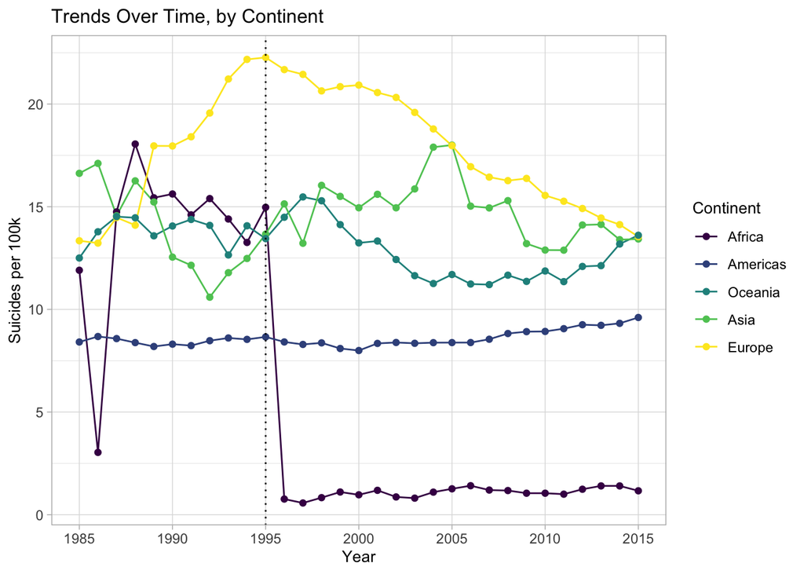

```r
continent_time_plot_one <- ggplot(continent_time, aes(x = year, y = suicide_per_100k, col = factor(continent))) +
  geom_line() +
  geom_point() +
  geom_vline(xintercept = 1995, linetype=3)+
  labs(title = "Trends Over Time, by Continent",
       x = "Year",
       y = "Suicides per 100k",
       color = "Continent") +
  theme(title = element_text(size = 10)) +
  scale_x_continuous(breaks = seq(1985, 2015, 5), minor_breaks = F)
continent_time_plot_one
```

Based on the above analysis, we might want to introduce the
$$\mathrm{Continent}\times \mathrm{Time}_{ij}$$
interaction, because the for different continent, the trend of suicide rate seems to be different.

# 4 Age difference

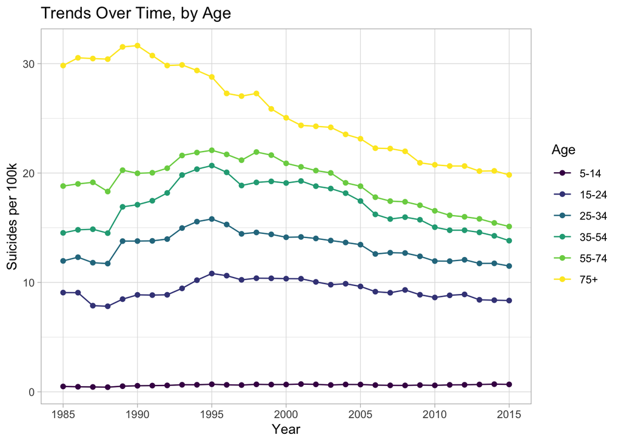

```r
### with time
age_time_plot <- data %>%
  group_by(year, age) %>%
  summarize(suicide_per_100k = (sum(as.numeric(suicides_no)) / sum(as.numeric(population))) * 100000) %>%
  ggplot(aes(x = year, y = suicide_per_100k, col = age)) +
  geom_line() +
  geom_point() +
  labs(title = "Trends Over Time, by Age",
       x = "Year",
       y = "Suicides per 100k",
       color = "Age") +
  scale_x_continuous(breaks = seq(1985, 2015, 5), minor_breaks = F)
age_time_plot
```

# 5 Gender difference

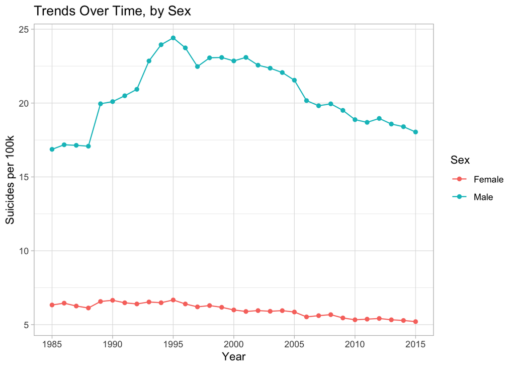

```r
data %>%
  group_by(year, sex) %>%
  summarize(suicide_per_100k = (sum(as.numeric(suicides_no)) / sum(as.numeric(population))) * 100000) %>%
  ggplot(aes(x = year, y = suicide_per_100k, col = sex)) +
  geom_line() +
  geom_point() +
  labs(title = "Trends Over Time, by Sex",
       x = "Year",
       y = "Suicides per 100k",
       color = "Sex") +
  scale_x_continuous(breaks = seq(1985, 2015, 5), minor_breaks = F)
```

# 6 GDP as a random effect

In [R-Exploratory](https://www.kaggle.com/lmorgan95/r-suicide-rates-in-depth-stats-insights?scriptVersionId=14410354), Morgan explored the potential correlation effect between suicide rate and GDP.

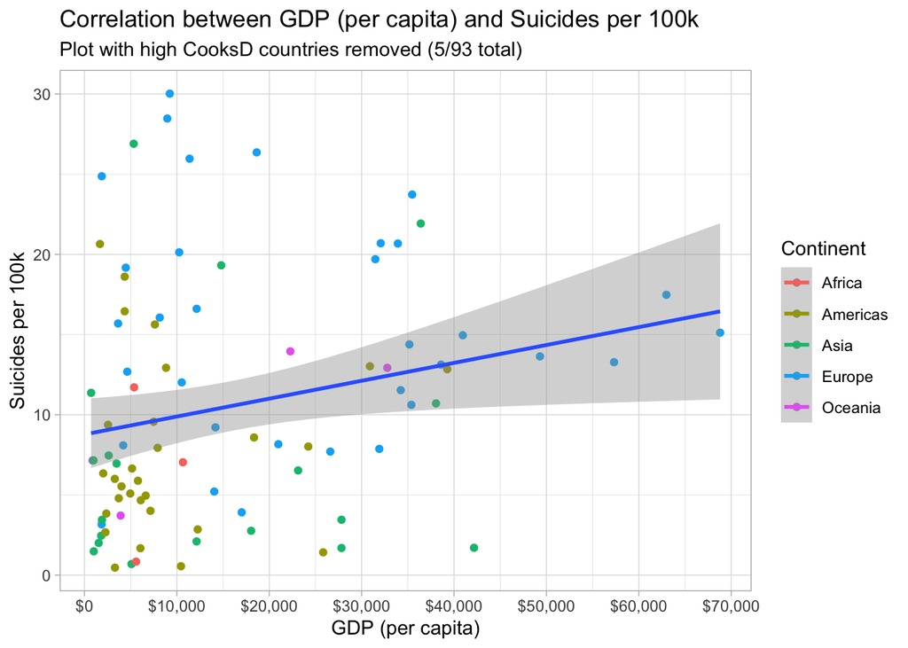

```r
country_mean_gdp <- data %>%
  group_by(country, continent) %>%
  summarize(suicide_per_100k = (sum(as.numeric(suicides_no)) / sum(as.numeric(population))) * 100000,
            gdp_per_capita = mean(gdp_per_capita))

model1 <- lm(suicide_per_100k ~ gdp_per_capita, data = country_mean_gdp)

gdp_suicide_no_outliers <- model1 %>%
  augment() %>%
  arrange(desc(.cooksd)) %>%
  filter(.cooksd < 4/nrow(.)) %>% # removes 5/93 countries
  inner_join(country_mean_gdp, by = c("suicide_per_100k", "gdp_per_capita")) %>%
  select(country, continent, gdp_per_capita, suicide_per_100k)

ggplot(gdp_suicide_no_outliers, aes(x = gdp_per_capita, y = suicide_per_100k, col = continent)) +
  geom_point() +
  geom_smooth(method = "lm", aes(group = 1)) +
  scale_x_continuous(labels=scales::dollar_format(prefix="$"), breaks = seq(0, 70000, 10000)) +
  labs(title = "Correlation between GDP (per capita) and Suicides per 100k",
       subtitle = "Plot with high CooksD countries removed (5/93 total)",
       x = "GDP (per capita)",
       y = "Suicides per 100k",
       col = "Continent")
```

And conclude that the linear association between suicide rate and GDP is significant but only account for a small amount of variation. However, by simply looking at the scatter plot, we don’t have strong evidence to assume that the trend is linear. So we might want to treat GDP as a random slope.

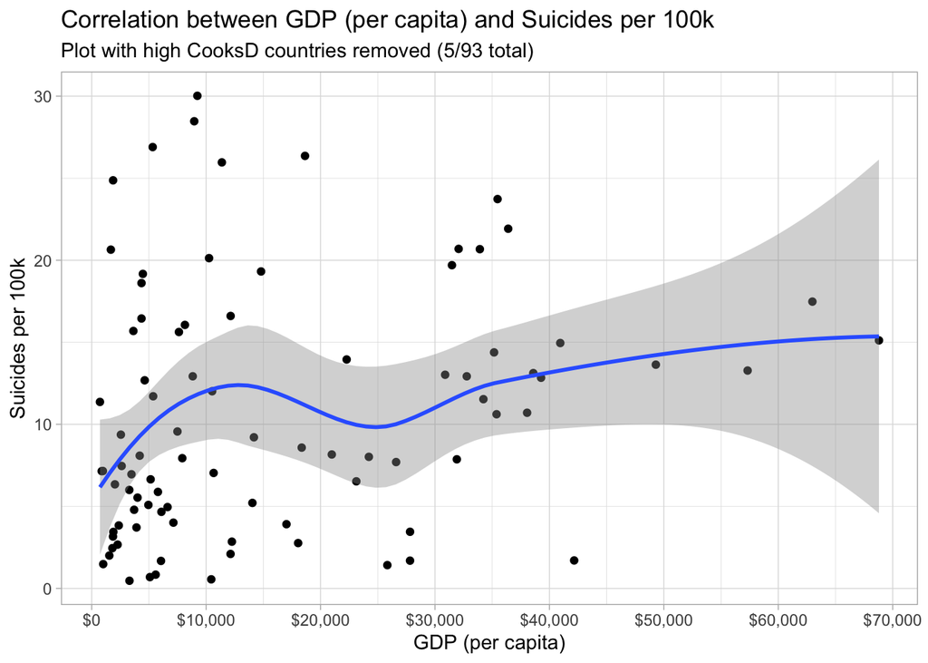

```r
ggplot(gdp_suicide_no_outliers, aes(x = gdp_per_capita, y = suicide_per_100k)) +
  geom_point() +
  geom_smooth(method = "loess", aes(group = 1)) +
  scale_x_continuous(labels=scales::dollar_format(prefix="$"), breaks = seq(0, 70000, 10000)) +
  labs(title = "Correlation between GDP (per capita) and Suicides per 100k",
       subtitle = "Plot with high CooksD countries removed (5/93 total)",
       x = "GDP (per capita)",
       y = "Suicides per 100k",
       col = "Continent")
```

# 7 Model

Based on the exploratory analysis, I think I will propose the following longitudinal model

$$\begin{aligned}
E(Y_{ij}) = &\beta_0 + \beta_1 \mathrm{Continent}_i + \beta_2 \mathrm{Sex}_i + \beta_3 \mathrm{Year}_{j}+\beta_4 (\mathrm{Year}_{ij} - 1995)_+ +\beta_5 \mathrm{Continent}_i\times \mathrm{Year}_{j} + \beta_6 \mathrm{Sex}_i\times \mathrm{Year}_{j} \\
&+ \beta_7 \mathrm{Sex}_i\times (\mathrm{Year}_{ij} - 1995)_+ + \beta_8 \mathrm{Continent}_i\times (\mathrm{Year}_{ij} - 1995)_+ + b_{1i} + b_{2i} \mathrm{Year}_{j} + b_{3i} (\mathrm{Year}_{ij} - 1995)_+ + b_{4i} \mathrm{GDP}_{ij} + \epsilon_{ij}
\end{aligned}$$

# 8 Remaining questions to address

- Model interpretation
- The specific knot in linear spline, 1995, 1996 or 2000?
- Model comparison
- Model diagnostic
- Model fitting method (REML, ML, GEE?)